# Sample document

# Code and verbatim

## Syntax highlighting

Here is a sample code chunk, just to show that syntax highlighting works as expected.

```r
not_null <- function (v) {
  if (!is.null(v)) return(paste(v, "not null"))
}
```

## Verbatim

Here is the structure of the `iris` dataset.

```r
str(iris)
```

```
'data.frame':   150 obs. of  5 variables:
 $ Sepal.Length: num  5.1 4.9 4.7 4.6 5 5.4 4.6 5 4.4 4.9 ...
 $ Sepal.Width : num  3.5 3 3.2 3.1 3.6 3.9 3.4 3.4 2.9 3.1 ...
 $ Petal.Length: num  1.4 1.4 1.3 1.5 1.4 1.7 1.4 1.5 1.4 1.5 ...
 $ Petal.Width : num  0.2 0.2 0.2 0.2 0.2 0.4 0.3 0.2 0.2 0.1 ...
 $ Species     : Factor w/ 3 levels "setosa","versicolor",..: 1 1 1 1 1 1 1 1 1 1 ...
```

# Tables

Here is a sample table output.

|  | (4.3,5.5] | (5.5,6.7] | (6.7,7.9] |
| --- | --- | --- | --- |
| (2,2.6] | 11 | 12 | 1 |
| (2.6,3.2] | 18 | 49 | 16 |
| (3.2,3.8] | 26 | 8 | 3 |
| (3.8,4.4] | 4 | 2 | 0 |

Here we display a crosstab displayed in several different ways with a “pills” interface. To do this, just pass your `table()` result to the `pilltabs()` function.

- Count
- Rows %
- Columns %
- Residuals

|  | (4.3,5.5] | (5.5,6.7] | (6.7,7.9] |
| --- | --- | --- | --- |
| setosa | 47 | 3 | 0 |
| versicolor | 11 | 36 | 3 |
| virginica | 1 | 32 | 17 |

|  | (4.3,5.5] | (5.5,6.7] | (6.7,7.9] | Total | n |
| --- | --- | --- | --- | --- | --- |
| setosa | 94.0 | 6.0 | 0.0 | 100 | 50 |
| versicolor | 22.0 | 72.0 | 6.0 | 100 | 50 |
| virginica | 2.0 | 64.0 | 34.0 | 100 | 50 |
| All | 39.3 | 47.3 | 13.3 | 100 | 150 |

|  | (4.3,5.5] | (5.5,6.7] | (6.7,7.9] | All |
| --- | --- | --- | --- | --- |
| setosa | 79.7 | 4.2 | 0 | 33.3 |
| versicolor | 18.6 | 50.7 | 15 | 33.3 |
| virginica | 1.7 | 45.1 | 85 | 33.3 |
| Total | 100.0 | 100.0 | 100 | 100.0 |
| n | 59.0 | 71.0 | 20 | 150.0 |

|  | (4.3,5.5] | (5.5,6.7] | (6.7,7.9] |
| --- | --- | --- | --- |
| setosa | 6.16 | -4.25 | -2.58 |
| versicolor | -1.95 | 2.54 | -1.42 |
| virginica | -4.21 | 1.71 | 4.00 |

X-squared = 111.6339, df = 4, p = < 2.2e-16

# Figures

## Base graphics

A base graphics histogram :

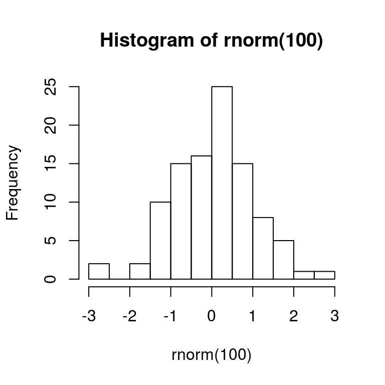

## ggplot2

Same with `ggplot2` :

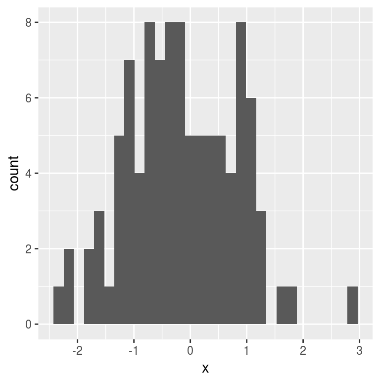

Beautiful ggplot2 histogram, really